# Tugas Pertemuan 3

# Pemodelan DLM & ARDL dengan Library `dynlm`

`L()` : fungsi untuk mengambil nilai lag dari suatu variabel.

`L(pm25)`= pm25 pada periode sebelumnya (lag ke-1).

`L(pm25, 2)` = pm25 pada dua periode sebelumnya (lag ke-2).

```r
#sama dengan model dlm q=1
cons_lm1 <- dynlm(AQI ~ pm25+L(pm25),data = train.ts)

#sama dengan model ardl p=1 q=0
cons_lm2 <- dynlm(AQI ~ pm25+L(AQI),data = train.ts)

#sama dengan ardl p=1 q=1
cons_lm3 <- dynlm(AQI ~ pm25+L(pm25)+L(AQI),data = train.ts)

#sama dengan dlm p=2
cons_lm4 <- dynlm(AQI ~ pm25+L(pm25)+L(pm25,2),data = train.ts)
```

## Ringkasan Model

Berikut adalah ringkasan hasil estimasi dari masing-masing model:

```r
summary(cons_lm1)
```

```
##
## Time series regression with "ts" data:
## Start = 2, End = 57
##
## Call:
## dynlm(formula = AQI ~ pm25 + L(pm25), data = train.ts)
##
## Residuals:
##     Min      1Q  Median      3Q     Max
## -4.8774 -1.3623 -0.4143  0.9707  4.3977
##
## Coefficients:
##             Estimate Std. Error t value Pr(>|t|)
## (Intercept)   31.354      1.426  21.986  < 2e-16 ***
## pm25          -4.509      1.644  -2.744  0.00828 **
## L(pm25)        2.431      1.161   2.095  0.04098 *
## ---
## Signif. codes:  0 '***' 0.001 '**' 0.01 '*' 0.05 '.' 0.1 ' ' 1
##
## Residual standard error: 2.011 on 53 degrees of freedom
## Multiple R-squared:  0.1505, Adjusted R-squared:  0.1184
## F-statistic: 4.694 on 2 and 53 DF,  p-value: 0.01328
```

```r
summary(cons_lm2)
```

```
##
## Time series regression with "ts" data:
## Start = 2, End = 57
##
## Call:
## dynlm(formula = AQI ~ pm25 + L(AQI), data = train.ts)
##
## Residuals:
##      Min       1Q   Median       3Q      Max
## -2.18297 -0.59646 -0.04547  0.58794  2.19134
##
## Coefficients:
##             Estimate Std. Error t value Pr(>|t|)
## (Intercept)  4.38211    1.75064   2.503   0.0154 *
## pm25        -0.51661    0.26111  -1.979   0.0531 .
## L(AQI)       0.87542    0.05716  15.315   <2e-16 ***
## ---
## Signif. codes:  0 '***' 0.001 '**' 0.01 '*' 0.05 '.' 0.1 ' ' 1
##
## Residual standard error: 0.8983 on 53 degrees of freedom
## Multiple R-squared:  0.8304, Adjusted R-squared:  0.8241
## F-statistic: 129.8 on 2 and 53 DF,  p-value: < 2.2e-16
```

```r
summary(cons_lm3)
```

```
##
## Time series regression with "ts" data:
## Start = 2, End = 57
##
## Call:
## dynlm(formula = AQI ~ pm25 + L(pm25) + L(AQI), data = train.ts)
##
## Residuals:
##      Min       1Q   Median       3Q      Max
## -2.19437 -0.53377 -0.07398  0.53245  2.18819
##
## Coefficients:
##             Estimate Std. Error t value Pr(>|t|)
## (Intercept)  3.84416    2.00316   1.919   0.0605 .
## pm25        -0.09036    0.79948  -0.113   0.9104
## L(pm25)     -0.31343    0.55520  -0.565   0.5748
## L(AQI)       0.88721    0.06120  14.496   <2e-16 ***
## ---
## Signif. codes:  0 '***' 0.001 '**' 0.01 '*' 0.05 '.' 0.1 ' ' 1
##
## Residual standard error: 0.9041 on 52 degrees of freedom
## Multiple R-squared:  0.8315, Adjusted R-squared:  0.8218
## F-statistic: 85.52 on 3 and 52 DF,  p-value: < 2.2e-16
```

```r
summary(cons_lm4)
```

```
##
## Time series regression with "ts" data:
## Start = 3, End = 57
##
## Call:
## dynlm(formula = AQI ~ pm25 + L(pm25) + L(pm25, 2), data = train.ts)
##
## Residuals:
##     Min      1Q  Median      3Q     Max
## -4.3400 -1.1824 -0.0772  1.0259  4.0422
##
## Coefficients:
##             Estimate Std. Error t value Pr(>|t|)
## (Intercept)   35.139      1.715  20.485  < 2e-16 ***
## pm25          -7.940      2.282  -3.480  0.00104 **
## L(pm25)        6.040      3.265   1.850  0.07012 .
## L(pm25, 2)    -2.033      1.571  -1.294  0.20149
## ---
## Signif. codes:  0 '***' 0.001 '**' 0.01 '*' 0.05 '.' 0.1 ' ' 1
##
## Residual standard error: 1.848 on 51 degrees of freedom
## Multiple R-squared:  0.3066, Adjusted R-squared:  0.2658
## F-statistic: 7.516 on 3 and 51 DF,  p-value: 0.0002938
```

## SSE

Selain ringkasan hasil, kita juga bisa menghitung nilai SSE dari masing-masing model.

```r
deviance(cons_lm1)
```

```
## [1] 214.2624
```

```r
deviance(cons_lm2)
```

```
## [1] 42.76382
```

```r
deviance(cons_lm3)
```

```
## [1] 42.50333
```

```r
deviance(cons_lm4)
```

```
## [1] 174.1227
```

Semakin kecil nilai SSE, berarti model lebih baik dalam menyesuaikan data (karena error lebih kecil).

## Ui encomptest

Membandingkan kinerja antar model. Salah satu pendekatan yang dapat digunakan adalah encompassing test dengan fungsi `encomptest()` dari package `lmtest`.

```r
#uji model
if(require("lmtest")) encomptest(cons_lm1, cons_lm2)
```

|  | Res.Df | Df | F | Pr(>F) |
| --- | --- | --- | --- | --- |
| M1 vs. ME | 52 | -1 | 210.1357833 | 6.641984e-20 |
| M2 vs. ME | 52 | -1 | 0.3187012 | 5.748165e-01 |

### Uji Autokorelasi Residual

```r
#durbin watson
dwtest(cons_lm1)
```

```
##
##  Durbin-Watson test
##
## data:  cons_lm1
## DW = 0.36907, p-value = 3.414e-16
## alternative hypothesis: true autocorrelation is greater than 0
```

```r
dwtest(cons_lm2)
```

```
##
##  Durbin-Watson test
##
## data:  cons_lm2
## DW = 1.1212, p-value = 0.0001009
## alternative hypothesis: true autocorrelation is greater than 0
```

```r
dwtest(cons_lm3)
```

```
##
##  Durbin-Watson test
##
## data:  cons_lm3
## DW = 1.1026, p-value = 5.088e-05
## alternative hypothesis: true autocorrelation is greater than 0
```

```r
dwtest(cons_lm4)
```

```
##
##  Durbin-Watson test
##
## data:  cons_lm4
## DW = 0.6555, p-value = 1.065e-09
## alternative hypothesis: true autocorrelation is greater than 0
```

### Uji Heterogenitas

```r
bptest(cons_lm1)
```

```
##
##  studentized Breusch-Pagan test
##
## data:  cons_lm1
## BP = 8.3784, df = 2, p-value = 0.01516
```

```r
bptest(cons_lm2)
```

```
##
##  studentized Breusch-Pagan test
##
## data:  cons_lm2
## BP = 0.52283, df = 2, p-value = 0.77
```

```r
bptest(cons_lm3)
```

```
##
##  studentized Breusch-Pagan test
##
## data:  cons_lm3
## BP = 0.70096, df = 3, p-value = 0.873
```

```r
bptest(cons_lm4)
```

```
##
##  studentized Breusch-Pagan test
##
## data:  cons_lm4
## BP = 13.272, df = 3, p-value = 0.004084
```

- Jika p-value > 0.05 → tidak ada heteroskedastisitas
- Jika p-value ≤ 0.05 → ada heteroskedastisitas.

### Uji Normalitas

H0: Residual berdistribusi normal.

H1: Residual tidak berdistribusi normal.

```r
shapiro.test(residuals(cons_lm1))
```

```
##
##  Shapiro-Wilk normality test
##
## data:  residuals(cons_lm1)
## W = 0.96118, p-value = 0.06876
```

```r
shapiro.test(residuals(cons_lm2))
```

```
##
##  Shapiro-Wilk normality test
##
## data:  residuals(cons_lm2)
## W = 0.9849, p-value = 0.7062
```

```r
shapiro.test(residuals(cons_lm3))
```

```
##
##  Shapiro-Wilk normality test
##
## data:  residuals(cons_lm3)
## W = 0.98134, p-value = 0.5352
```

```r
shapiro.test(residuals(cons_lm4))
```

```
##
##  Shapiro-Wilk normality test
##
## data:  residuals(cons_lm4)
## W = 0.97474, p-value = 0.2976
```

- Jika p-value > 0.05 → gagal tolak H0 → residual normal.
- Jika p-value ≤ 0.05 → tolak H0 → residual tidak normal.

# Perbandingan Model

Membuat tabel ringkas akurasi model berdasarkan nilai MAPE (Mean Absolute Percentage Error).

```r
akurasi <- matrix(c(mape.koyck, mape.dlm, mape.dlm2,mape.ardl, mape.ardl.opt))
row.names(akurasi)<- c("Koyck","DLM 1","DLM 2","Autoregressive","Autoregressive Opt")
colnames(akurasi) <- c("MAPE")
akurasi
```

```
##                         MAPE
## Koyck              0.1394956
## DLM 1              0.1278542
## DLM 2              0.1088656
## Autoregressive     0.1543609
## Autoregressive Opt 0.2814882
```

Berdasarkan nilai MAPE, model paling optimum didapat pada Model DLM 2 karena memiliki nilai MAPE yang terkecil.

## Plot

Untuk membandingkan hasil peramalan dari berbagai model (Koyck, DLM 1, DLM 2, dan ARDL) dengan data aktual, dibuat grafik garis. Visualisasi ini membantu melihat seberapa dekat hasil ramalan tiap model dengan nilai aktual.

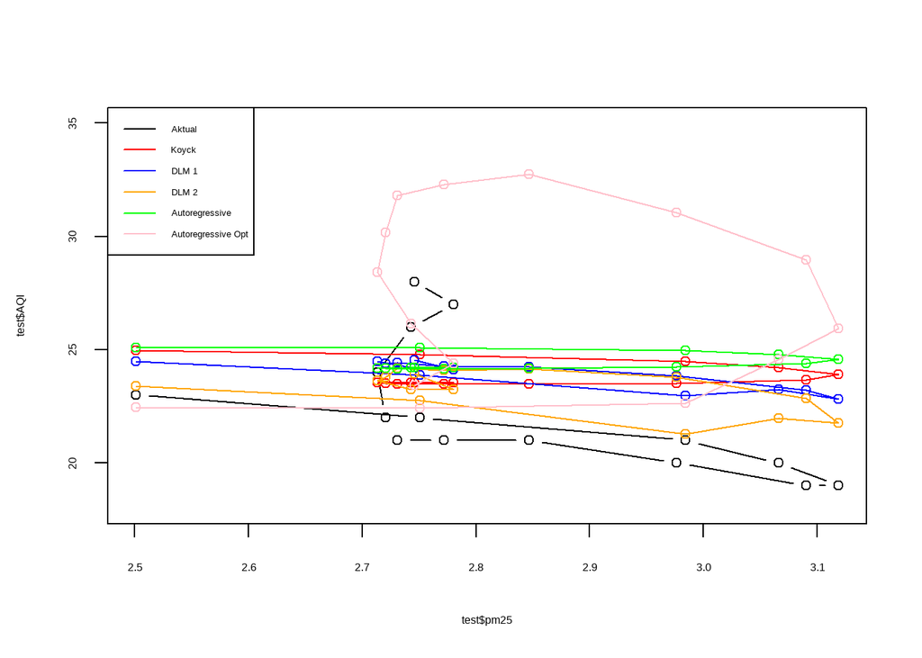

```r
par(mfrow=c(1,1))  # atur layout grafik tunggal

# plot data aktual
plot(test$pm25, test$AQI, type="b", col="black", ylim=c(18,35))

# tambahkan garis ramalan dari masing-masing model
points(test$pm25, fore.koyck$forecasts, col="red");   lines(test$pm25, fore.koyck$forecasts, col="red")
points(test$pm25, fore.dlm$forecasts, col="blue");    lines(test$pm25, fore.dlm$forecasts, col="blue")
points(test$pm25, fore.dlm2$forecasts, col="orange"); lines(test$pm25, fore.dlm2$forecasts, col="orange")
points(test$pm25, fore.ardl$forecasts, col="green");  lines(test$pm25, fore.ardl$forecasts, col="green")
points(test$pm25, fore.ardl.opt$forecasts, col="pink");  lines(test$pm25, fore.ardl.opt$forecasts, col="pink")

# legenda model
legend("topleft",
       c("Aktual", "Koyck","DLM 1","DLM 2", "Autoregressive", "Autoregressive Opt"),
       lty=1, col=c("black","red","blue","orange","green","pink"), cex=0.8)
```